# Predictive Machine Learning Project

The Weight Lifting Exercise Dataset (WLE) as one of the Human Activity Recognition (HAR) systems predicts which activity was performed at a specific time. In the following demonstration we would like to qualify the determined task to let users know how well a task was performed.

## Cleaning the Data

We will now remove missing data. A ‘NA’ and ’’ designates missing data; columns that have more than half of the rows filled in will be kept; the others will be thrown away. We will also do away with the first several columns that are only used for sequencing the data.

```r
incompleteData <- sapply(colnames(data), function(x)
                          if(sum(is.na(data[, x]) | data[, x] == '') >
                             0.5*nrow(data)){return(TRUE)}else{return(FALSE)})
data <- data[, !incompleteData]
drop <- c("X", "user_name", "raw_timestamp_part_1", "raw_timestamp_part_2", "cvtd_timestamp", "new_window", "num_window")

data <- data[, !(names(data) %in% drop)]
```

## Exploratory Analysis

We would like to get a general idea of what the data looks like for various classes. To do this, it is easy to histogram each class accroding to the column. The “histogram” we will use is the “geom_violin()” method.

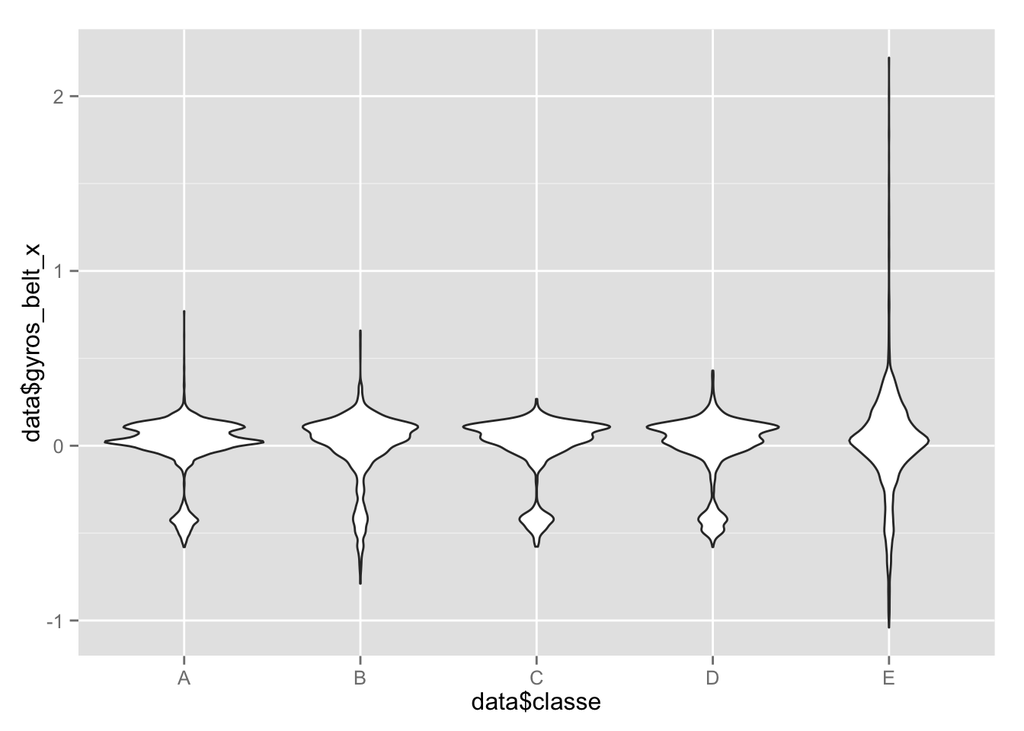

```r
p <- ggplot(data, aes(x=data$classe, y=data$gyros_belt_x, colors=data$classe))
p + geom_violin()
```

## Dividing up the data

We choose a training sample that is 70% of the original data. We will “quiz” it on the remaining 30% before we subject the model to the testing set.

```r
inTrain = createDataPartition(data$classe, p=0.70, list=FALSE)
training = data[inTrain,]
quizzing = data[-inTrain,]
```

## Developing a Model

We use a random forest model. The data is large and somewhat correlated so this model should work well.

```r
predictionModel <- randomForest(classe ~ ., data=training)
print(predictionModel)
```

```
##
## Call:
##  randomForest(formula = classe ~ ., data = training)
##                Type of random forest: classification
##                      Number of trees: 500
## No. of variables tried at each split: 7
##
##         OOB estimate of  error rate: 0.46%
## Confusion matrix:
##      A    B    C    D    E  class.error
## A 3904    1    0    0    1 0.0005120328
## B   11 2644    3    0    0 0.0052671181
## C    0   14 2378    4    0 0.0075125209
## D    0    0   21 2230    1 0.0097690941
## E    0    0    1    6 2518 0.0027722772
```

```r
importance(predictionModel)
```

```
##                      MeanDecreaseGini
## roll_belt                   908.95520
## pitch_belt                  483.82496
## yaw_belt                    608.94935
## total_accel_belt            132.61181
## gyros_belt_x                 69.68459
## gyros_belt_y                 77.29291
## gyros_belt_z                224.70168
## accel_belt_x                 78.42489
## accel_belt_y                 93.27018
## accel_belt_z                270.81865
## magnet_belt_x               181.30900
## magnet_belt_y               273.39678
## magnet_belt_z               293.91019
## roll_arm                    224.19658
## pitch_arm                   120.62547
## yaw_arm                     172.17003
## total_accel_arm              71.40235
## gyros_arm_x                  92.51570
## gyros_arm_y                 100.00569
## gyros_arm_z                  42.95408
## accel_arm_x                 162.31342
## accel_arm_y                 106.98234
## accel_arm_z                  91.55667
## magnet_arm_x                184.26506
## magnet_arm_y                155.24204
## magnet_arm_z                126.34510
## roll_dumbbell               299.12469
## pitch_dumbbell              119.27784
## yaw_dumbbell                185.43108
## total_accel_dumbbell        184.67628
## gyros_dumbbell_x             91.80096
## gyros_dumbbell_y            157.13971
## gyros_dumbbell_z             58.12402
## accel_dumbbell_x            180.27186
## accel_dumbbell_y            309.27502
## accel_dumbbell_z            228.15294
## magnet_dumbbell_x           337.05098
## magnet_dumbbell_y           476.10834
## magnet_dumbbell_z           527.17747
## roll_forearm                436.62403
## pitch_forearm               525.53612
## yaw_forearm                 119.08294
## total_accel_forearm          80.63809
## gyros_forearm_x              55.54959
## gyros_forearm_y              86.43182
## gyros_forearm_z              61.25902
## accel_forearm_x             222.03632
## accel_forearm_y              99.32578
## accel_forearm_z             170.95337
## magnet_forearm_x            146.50353
## magnet_forearm_y            157.46111
## magnet_forearm_z            197.79577
```

The confusion matrix shows that there is strong accuracy for this model.

```r
pred1 <-  predict( predictionModel, quizzing, type ="class")
confusionMatrix(pred1, quizzing$classe)
```

```
## Confusion Matrix and Statistics
##
##           Reference
## Prediction    A    B    C    D    E
##          A 1672    8    0    0    0
##          B    2 1129    3    0    0
##          C    0    2 1023   12    0
##          D    0    0    0  949    4
##          E    0    0    0    3 1078
##
## Overall Statistics
##
##                Accuracy : 0.9942
##                  95% CI : (0.9919, 0.996)
##     No Information Rate : 0.2845
##     P-Value [Acc > NIR] : < 2.2e-16
##
##                   Kappa : 0.9927
##  Mcnemar's Test P-Value : NA
##
## Statistics by Class:
##
##                      Class: A Class: B Class: C Class: D Class: E
## Sensitivity            0.9988   0.9912   0.9971   0.9844   0.9963
## Specificity            0.9981   0.9989   0.9971   0.9992   0.9994
## Pos Pred Value         0.9952   0.9956   0.9865   0.9958   0.9972
## Neg Pred Value         0.9995   0.9979   0.9994   0.9970   0.9992
## Prevalence             0.2845   0.1935   0.1743   0.1638   0.1839
## Detection Rate         0.2841   0.1918   0.1738   0.1613   0.1832
## Detection Prevalence   0.2855   0.1927   0.1762   0.1619   0.1837
## Balanced Accuracy      0.9985   0.9951   0.9971   0.9918   0.9978
```

Save the model for export.

```r
save(predictionModel, file="predictionModel.RData")
```

## The test

We first load the previous prediction model.

```r
load(file="predictionModel.RData", verbose=TRUE)
```

```
## Loading objects:
##   predictionModel
```

```r
testData <-read.csv("pml-testing.csv")
td <- testData[, colnames(testData) %in% colnames(training)]
#testData <- predict(preProc, td[, valid, with=FALSE])
out <- predict(predictionModel, td, type = "class")
#td <- cbind(out , td)
#subset(td, select=names(td)[grep("belt|[^(fore)]arm|dumbbell|forearm", names(td), invert=TRUE)])
```

```r
pml_write_files = function(x){
  n = length(x)
  for(i in 1:n){
    filename = paste0("problem_id_",i,".txt")
    write.table(x[i],file=filename,quote=FALSE,row.names=FALSE,col.names=FALSE)
  }
}

pml_write_files(out)
```